# Risk Factor Analysis

## Outcome Variable

**Outcome Variable:** stunted

## Predictor Variables

**Intervention Variable:** birthwt

**Adjustment Set:**

- arm
- sex
- W_mage
- meducyrs
- feducyrs
- vagbrth
- single
- brthmon
- W_parity
- delta_W_mage
- delta_meducyrs
- delta_feducyrs
- delta_vagbrth
- delta_single
- delta_brthmon
- delta_W_parity

## Stratifying Variables

The analysis was stratified on these variable(s):

- agecat
- studyid
- country

## Data Summary

| agecat | studyid | country | birthwt | stunted | n_cell | n |
| --- | --- | --- | --- | --- | --- | --- |
| Birth | ki0047075b-MAL-ED | BANGLADESH | Normal or high birthweight | 0 | 163 | 231 |
| Birth | ki0047075b-MAL-ED | BANGLADESH | Normal or high birthweight | 1 | 14 | 231 |
| Birth | ki0047075b-MAL-ED | BANGLADESH | Low birthweight | 0 | 24 | 231 |
| Birth | ki0047075b-MAL-ED | BANGLADESH | Low birthweight | 1 | 30 | 231 |
| Birth | ki0047075b-MAL-ED | BRAZIL | Normal or high birthweight | 0 | 55 | 65 |
| Birth | ki0047075b-MAL-ED | BRAZIL | Normal or high birthweight | 1 | 6 | 65 |
| Birth | ki0047075b-MAL-ED | BRAZIL | Low birthweight | 0 | 1 | 65 |
| Birth | ki0047075b-MAL-ED | BRAZIL | Low birthweight | 1 | 3 | 65 |
| Birth | ki0047075b-MAL-ED | INDIA | Normal or high birthweight | 0 | 34 | 47 |
| Birth | ki0047075b-MAL-ED | INDIA | Normal or high birthweight | 1 | 5 | 47 |
| Birth | ki0047075b-MAL-ED | INDIA | Low birthweight | 0 | 3 | 47 |
| Birth | ki0047075b-MAL-ED | INDIA | Low birthweight | 1 | 5 | 47 |
| Birth | ki0047075b-MAL-ED | NEPAL | Normal or high birthweight | 0 | 24 | 27 |
| Birth | ki0047075b-MAL-ED | NEPAL | Normal or high birthweight | 1 | 0 | 27 |
| Birth | ki0047075b-MAL-ED | NEPAL | Low birthweight | 0 | 1 | 27 |
| Birth | ki0047075b-MAL-ED | NEPAL | Low birthweight | 1 | 2 | 27 |
| Birth | ki0047075b-MAL-ED | PERU | Normal or high birthweight | 0 | 205 | 233 |
| Birth | ki0047075b-MAL-ED | PERU | Normal or high birthweight | 1 | 16 | 233 |
| Birth | ki0047075b-MAL-ED | PERU | Low birthweight | 0 | 2 | 233 |
| Birth | ki0047075b-MAL-ED | PERU | Low birthweight | 1 | 10 | 233 |
| Birth | ki0047075b-MAL-ED | SOUTH AFRICA | Normal or high birthweight | 0 | 109 | 123 |
| Birth | ki0047075b-MAL-ED | SOUTH AFRICA | Normal or high birthweight | 1 | 6 | 123 |
| Birth | ki0047075b-MAL-ED | SOUTH AFRICA | Low birthweight | 0 | 4 | 123 |
| Birth | ki0047075b-MAL-ED | SOUTH AFRICA | Low birthweight | 1 | 4 | 123 |
| Birth | ki0047075b-MAL-ED | TANZANIA, UNITED REPUBLIC OF | Normal or high birthweight | 0 | 102 | 125 |
| Birth | ki0047075b-MAL-ED | TANZANIA, UNITED REPUBLIC OF | Normal or high birthweight | 1 | 16 | 125 |
| Birth | ki0047075b-MAL-ED | TANZANIA, UNITED REPUBLIC OF | Low birthweight | 0 | 0 | 125 |
| Birth | ki0047075b-MAL-ED | TANZANIA, UNITED REPUBLIC OF | Low birthweight | 1 | 7 | 125 |
| Birth | ki1000108-CMC-V-BCS-2002 | INDIA | Normal or high birthweight | 0 | 71 | 92 |
| Birth | ki1000108-CMC-V-BCS-2002 | INDIA | Normal or high birthweight | 1 | 10 | 92 |

[output cut: 282 more lines]

The following strata were considered:

- agecat: 24 months, studyid: ki0047075b-MAL-ED, country: BANGLADESH
- agecat: 24 months, studyid: ki0047075b-MAL-ED, country: BRAZIL
- agecat: 24 months, studyid: ki0047075b-MAL-ED, country: INDIA
- agecat: 24 months, studyid: ki0047075b-MAL-ED, country: NEPAL
- agecat: 24 months, studyid: ki0047075b-MAL-ED, country: PERU
- agecat: 24 months, studyid: ki0047075b-MAL-ED, country: SOUTH AFRICA
- agecat: 24 months, studyid: ki0047075b-MAL-ED, country: TANZANIA, UNITED REPUBLIC OF
- agecat: 24 months, studyid: ki1000108-CMC-V-BCS-2002, country: INDIA
- agecat: 24 months, studyid: ki1000108-IRC, country: INDIA
- agecat: 24 months, studyid: ki1000109-EE, country: PAKISTAN
- agecat: 24 months, studyid: ki1017093-NIH-Birth, country: BANGLADESH
- agecat: 24 months, studyid: ki1017093b-PROVIDE, country: BANGLADESH
- agecat: 24 months, studyid: ki1017093c-NIH-Crypto, country: BANGLADESH
- agecat: 24 months, studyid: ki1066203-TanzaniaChild2, country: TANZANIA, UNITED REPUBLIC OF
- agecat: 24 months, studyid: ki1101329-Keneba, country: GAMBIA
- agecat: 24 months, studyid: ki1113344-GMS-Nepal, country: NEPAL
- agecat: 24 months, studyid: ki1114097-CMIN, country: BANGLADESH
- agecat: 24 months, studyid: ki1114097-CONTENT, country: PERU
- agecat: 24 months, studyid: ki1119695-PROBIT, country: BELARUS
- agecat: 24 months, studyid: ki1126311-ZVITAMBO, country: ZIMBABWE
- agecat: 24 months, studyid: ki1135781-COHORTS, country: GUATEMALA
- agecat: 24 months, studyid: ki1135781-COHORTS, country: INDIA
- agecat: 24 months, studyid: ki1135781-COHORTS, country: PHILIPPINES
- agecat: 24 months, studyid: kiGH5241-JiVitA-3, country: BANGLADESH
- agecat: 24 months, studyid: kiGH5241-JiVitA-4, country: BANGLADESH
- agecat: 6 months, studyid: ki0047075b-MAL-ED, country: BANGLADESH
- agecat: 6 months, studyid: ki0047075b-MAL-ED, country: BRAZIL
- agecat: 6 months, studyid: ki0047075b-MAL-ED, country: INDIA
- agecat: 6 months, studyid: ki0047075b-MAL-ED, country: NEPAL
- agecat: 6 months, studyid: ki0047075b-MAL-ED, country: PERU
- agecat: 6 months, studyid: ki0047075b-MAL-ED, country: SOUTH AFRICA
- agecat: 6 months, studyid: ki0047075b-MAL-ED, country: TANZANIA, UNITED REPUBLIC OF
- agecat: 6 months, studyid: ki1000108-CMC-V-BCS-2002, country: INDIA
- agecat: 6 months, studyid: ki1000108-IRC, country: INDIA
- agecat: 6 months, studyid: ki1000109-EE, country: PAKISTAN
- agecat: 6 months, studyid: ki1000109-ResPak, country: PAKISTAN
- agecat: 6 months, studyid: ki1000304b-SAS-CompFeed, country: INDIA
- agecat: 6 months, studyid: ki1017093-NIH-Birth, country: BANGLADESH
- agecat: 6 months, studyid: ki1017093b-PROVIDE, country: BANGLADESH
- agecat: 6 months, studyid: ki1017093c-NIH-Crypto, country: BANGLADESH
- agecat: 6 months, studyid: ki1066203-TanzaniaChild2, country: TANZANIA, UNITED REPUBLIC OF
- agecat: 6 months, studyid: ki1101329-Keneba, country: GAMBIA
- agecat: 6 months, studyid: ki1113344-GMS-Nepal, country: NEPAL
- agecat: 6 months, studyid: ki1114097-CMIN, country: BANGLADESH
- agecat: 6 months, studyid: ki1114097-CONTENT, country: PERU
- agecat: 6 months, studyid: ki1119695-PROBIT, country: BELARUS
- agecat: 6 months, studyid: ki1126311-ZVITAMBO, country: ZIMBABWE
- agecat: 6 months, studyid: ki1135781-COHORTS, country: GUATEMALA
- agecat: 6 months, studyid: ki1135781-COHORTS, country: INDIA
- agecat: 6 months, studyid: ki1135781-COHORTS, country: PHILIPPINES
- agecat: 6 months, studyid: kiGH5241-JiVitA-3, country: BANGLADESH
- agecat: 6 months, studyid: kiGH5241-JiVitA-4, country: BANGLADESH
- agecat: Birth, studyid: ki0047075b-MAL-ED, country: BANGLADESH
- agecat: Birth, studyid: ki0047075b-MAL-ED, country: BRAZIL
- agecat: Birth, studyid: ki0047075b-MAL-ED, country: INDIA
- agecat: Birth, studyid: ki0047075b-MAL-ED, country: NEPAL
- agecat: Birth, studyid: ki0047075b-MAL-ED, country: PERU
- agecat: Birth, studyid: ki0047075b-MAL-ED, country: SOUTH AFRICA
- agecat: Birth, studyid: ki0047075b-MAL-ED, country: TANZANIA, UNITED REPUBLIC OF
- agecat: Birth, studyid: ki1000108-CMC-V-BCS-2002, country: INDIA
- agecat: Birth, studyid: ki1000108-IRC, country: INDIA
- agecat: Birth, studyid: ki1000109-EE, country: PAKISTAN
- agecat: Birth, studyid: ki1000109-ResPak, country: PAKISTAN
- agecat: Birth, studyid: ki1000304b-SAS-CompFeed, country: INDIA
- agecat: Birth, studyid: ki1017093-NIH-Birth, country: BANGLADESH
- agecat: Birth, studyid: ki1017093b-PROVIDE, country: BANGLADESH
- agecat: Birth, studyid: ki1017093c-NIH-Crypto, country: BANGLADESH
- agecat: Birth, studyid: ki1101329-Keneba, country: GAMBIA
- agecat: Birth, studyid: ki1113344-GMS-Nepal, country: NEPAL
- agecat: Birth, studyid: ki1114097-CMIN, country: BANGLADESH
- agecat: Birth, studyid: ki1114097-CONTENT, country: PERU
- agecat: Birth, studyid: ki1119695-PROBIT, country: BELARUS
- agecat: Birth, studyid: ki1126311-ZVITAMBO, country: ZIMBABWE
- agecat: Birth, studyid: ki1135781-COHORTS, country: GUATEMALA
- agecat: Birth, studyid: ki1135781-COHORTS, country: INDIA
- agecat: Birth, studyid: ki1135781-COHORTS, country: PHILIPPINES
- agecat: Birth, studyid: kiGH5241-JiVitA-3, country: BANGLADESH
- agecat: Birth, studyid: kiGH5241-JiVitA-4, country: BANGLADESH

### Dropped Strata

Some strata were dropped due to rare outcomes:

- agecat: Birth, studyid: ki0047075b-MAL-ED, country: BRAZIL
- agecat: Birth, studyid: ki0047075b-MAL-ED, country: INDIA
- agecat: Birth, studyid: ki0047075b-MAL-ED, country: NEPAL
- agecat: Birth, studyid: ki0047075b-MAL-ED, country: PERU
- agecat: Birth, studyid: ki0047075b-MAL-ED, country: SOUTH AFRICA
- agecat: Birth, studyid: ki0047075b-MAL-ED, country: TANZANIA, UNITED REPUBLIC OF
- agecat: Birth, studyid: ki1000108-CMC-V-BCS-2002, country: INDIA
- agecat: Birth, studyid: ki1000109-ResPak, country: PAKISTAN
- agecat: Birth, studyid: ki1114097-CMIN, country: BANGLADESH
- agecat: Birth, studyid: ki1114097-CONTENT, country: PERU
- agecat: Birth, studyid: ki1119695-PROBIT, country: BELARUS
- agecat: 6 months, studyid: ki0047075b-MAL-ED, country: BRAZIL
- agecat: 6 months, studyid: ki0047075b-MAL-ED, country: NEPAL
- agecat: 6 months, studyid: ki0047075b-MAL-ED, country: TANZANIA, UNITED REPUBLIC OF
- agecat: 6 months, studyid: ki1000109-ResPak, country: PAKISTAN
- agecat: 6 months, studyid: ki1114097-CMIN, country: BANGLADESH
- agecat: 6 months, studyid: ki1114097-CONTENT, country: PERU
- agecat: 6 months, studyid: ki1119695-PROBIT, country: BELARUS
- agecat: 24 months, studyid: ki0047075b-MAL-ED, country: BRAZIL
- agecat: 24 months, studyid: ki0047075b-MAL-ED, country: PERU
- agecat: 24 months, studyid: ki0047075b-MAL-ED, country: SOUTH AFRICA
- agecat: 24 months, studyid: ki0047075b-MAL-ED, country: TANZANIA, UNITED REPUBLIC OF
- agecat: 24 months, studyid: ki1066203-TanzaniaChild2, country: TANZANIA, UNITED REPUBLIC OF
- agecat: 24 months, studyid: ki1114097-CMIN, country: BANGLADESH
- agecat: 24 months, studyid: ki1114097-CONTENT, country: PERU
- agecat: 24 months, studyid: ki1119695-PROBIT, country: BELARUS
- agecat: 24 months, studyid: ki1135781-COHORTS, country: GUATEMALA

## Methods Detail

We’re interested in the causal parameters $E[Y_a]$ for all values of $a \in \mathcal{A}$. These parameters represent the mean outcome if, possibly contrary to fact, we intervened to set all units to have $A=a$. Under the randomization and positivity assumptions, these are identified by the statistical parameters $\psi_a=E_W[E_{Y|A,W}(Y|A=a,W)]$. In addition, we’re interested in the mean of $Y$, $E[Y]$ under no intervention (the observed mean). We will estimate these parameters by using SuperLearner to fit the relevant likelihood factors – $E_{Y|A,W}(Y|A=a,W)$ and $p(A=a|W)$, and then updating our likelihood fit using a joint TMLE.

For unadjusted analyses ($W=\{\}$), initial likelihoods were estimated using Lrnr_glm to estimate the simple $E(Y|A)$ and Lrnr_mean to estimate $p(A)$. For adjusted analyses, a small library containing Lrnr_glmnet, Lrnr_xgboost, and Lrnr_mean was used.

Having estimated these parameters, we will then use the delta method to estimate relative risks and attributable risks relative to a prespecified baseline level of $A$.

# Results Detail

## Results Plots

[figure not shown]

[figure not shown]

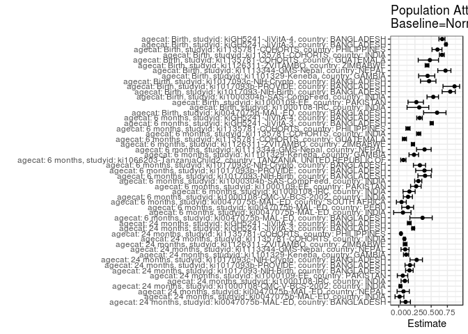

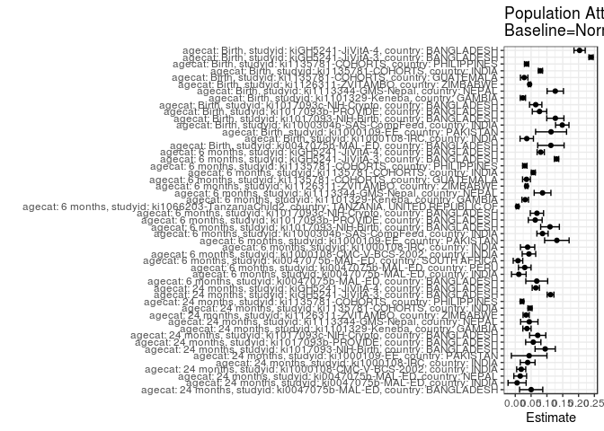

## Results Table

### Parameter: TSM

| agecat | studyid | country | intervention_level | baseline_level | estimate | ci_lower | ci_upper |
| --- | --- | --- | --- | --- | --- | --- | --- |
| Birth | ki0047075b-MAL-ED | BANGLADESH | Normal or high birthweight | NA | 0.0778913 | 0.0381324 | 0.1176502 |
| Birth | ki0047075b-MAL-ED | BANGLADESH | Low birthweight | NA | 0.5809782 | 0.4425694 | 0.7193870 |
| Birth | ki1000108-IRC | INDIA | Normal or high birthweight | NA | 0.0785872 | 0.0488296 | 0.1083448 |
| Birth | ki1000108-IRC | INDIA | Low birthweight | NA | 0.2700510 | 0.1563605 | 0.3837415 |
| Birth | ki1000109-EE | PAKISTAN | Normal or high birthweight | NA | 0.3035171 | 0.2300960 | 0.3769383 |
| Birth | ki1000109-EE | PAKISTAN | Low birthweight | NA | 0.6704069 | 0.5643343 | 0.7764794 |
| Birth | ki1000304b-SAS-CompFeed | INDIA | Normal or high birthweight | NA | 0.1302808 | 0.0958299 | 0.1647317 |
| Birth | ki1000304b-SAS-CompFeed | INDIA | Low birthweight | NA | 0.6831806 | 0.6230479 | 0.7433133 |
| Birth | ki1017093-NIH-Birth | BANGLADESH | Normal or high birthweight | NA | 0.0328477 | 0.0158303 | 0.0498651 |
| Birth | ki1017093-NIH-Birth | BANGLADESH | Low birthweight | NA | 0.4527197 | 0.3807314 | 0.5247081 |
| Birth | ki1017093b-PROVIDE | BANGLADESH | Normal or high birthweight | NA | 0.0124378 | 0.0015937 | 0.0232819 |
| Birth | ki1017093b-PROVIDE | BANGLADESH | Low birthweight | NA | 0.3138686 | 0.2360885 | 0.3916487 |
| Birth | ki1017093c-NIH-Crypto | BANGLADESH | Normal or high birthweight | NA | 0.0734093 | 0.0517797 | 0.0950388 |
| Birth | ki1017093c-NIH-Crypto | BANGLADESH | Low birthweight | NA | 0.3509644 | 0.2783764 | 0.4235524 |
| Birth | ki1101329-Keneba | GAMBIA | Normal or high birthweight | NA | 0.0301273 | 0.0208262 | 0.0394285 |
| Birth | ki1101329-Keneba | GAMBIA | Low birthweight | NA | 0.1904426 | 0.1370460 | 0.2438393 |
| Birth | ki1113344-GMS-Nepal | NEPAL | Normal or high birthweight | NA | 0.0488883 | 0.0293354 | 0.0684413 |
| Birth | ki1113344-GMS-Nepal | NEPAL | Low birthweight | NA | 0.4404910 | 0.3738119 | 0.5071702 |
| Birth | ki1126311-ZVITAMBO | ZIMBABWE | Normal or high birthweight | NA | 0.0582985 | 0.0540908 | 0.0625063 |
| Birth | ki1126311-ZVITAMBO | ZIMBABWE | Low birthweight | NA | 0.3908460 | 0.3684379 | 0.4132541 |
| Birth | ki1135781-COHORTS | GUATEMALA | Normal or high birthweight | NA | 0.0305212 | 0.0178411 | 0.0432013 |
| Birth | ki1135781-COHORTS | GUATEMALA | Low birthweight | NA | 0.3888854 | 0.2709361 | 0.5068347 |
| Birth | ki1135781-COHORTS | INDIA | Normal or high birthweight | NA | 0.0397427 | 0.0344472 | 0.0450383 |
| Birth | ki1135781-COHORTS | INDIA | Low birthweight | NA | 0.4255597 | 0.3990171 | 0.4521024 |
| Birth | ki1135781-COHORTS | PHILIPPINES | Normal or high birthweight | NA | 0.0241500 | 0.0183646 | 0.0299355 |
| Birth | ki1135781-COHORTS | PHILIPPINES | Low birthweight | NA | 0.3873385 | 0.3313416 | 0.4433353 |
| Birth | kiGH5241-JiVitA-3 | BANGLADESH | Normal or high birthweight | NA | 0.0894887 | 0.0837069 | 0.0952706 |
| Birth | kiGH5241-JiVitA-3 | BANGLADESH | Low birthweight | NA | 0.6506825 | 0.6401382 | 0.6612268 |
| Birth | kiGH5241-JiVitA-4 | BANGLADESH | Normal or high birthweight | NA | 0.1002891 | 0.0838413 | 0.1167370 |
| Birth | kiGH5241-JiVitA-4 | BANGLADESH | Low birthweight | NA | 0.6630111 | 0.6277869 | 0.6982354 |

[output cut: 72 more lines]

### Parameter: E(Y)

| agecat | studyid | country | intervention_level | baseline_level | estimate | ci_lower | ci_upper |
| --- | --- | --- | --- | --- | --- | --- | --- |
| Birth | ki0047075b-MAL-ED | BANGLADESH | NA | NA | 0.1904762 | 0.1397281 | 0.2412242 |
| Birth | ki1000108-IRC | INDIA | NA | NA | 0.1148825 | 0.0829051 | 0.1468600 |
| Birth | ki1000109-EE | PAKISTAN | NA | NA | 0.4166667 | 0.3541635 | 0.4791698 |
| Birth | ki1000304b-SAS-CompFeed | INDIA | NA | NA | 0.2787540 | 0.2475949 | 0.3099131 |
| Birth | ki1017093-NIH-Birth | BANGLADESH | NA | NA | 0.1595395 | 0.1304091 | 0.1886699 |
| Birth | ki1017093b-PROVIDE | BANGLADESH | NA | NA | 0.0890538 | 0.0649864 | 0.1131212 |
| Birth | ki1017093c-NIH-Crypto | BANGLADESH | NA | NA | 0.1379781 | 0.1129774 | 0.1629789 |
| Birth | ki1101329-Keneba | GAMBIA | NA | NA | 0.0542838 | 0.0429232 | 0.0656445 |
| Birth | ki1113344-GMS-Nepal | NEPAL | NA | NA | 0.1752874 | 0.1470202 | 0.2035545 |
| Birth | ki1126311-ZVITAMBO | ZIMBABWE | NA | NA | 0.1035430 | 0.0984652 | 0.1086208 |
| Birth | ki1135781-COHORTS | GUATEMALA | NA | NA | 0.0586735 | 0.0422124 | 0.0751345 |
| Birth | ki1135781-COHORTS | INDIA | NA | NA | 0.1193130 | 0.1115144 | 0.1271117 |
| Birth | ki1135781-COHORTS | PHILIPPINES | NA | NA | 0.0599201 | 0.0514314 | 0.0684088 |
| Birth | kiGH5241-JiVitA-3 | BANGLADESH | NA | NA | 0.3289392 | 0.3215744 | 0.3363039 |
| Birth | kiGH5241-JiVitA-4 | BANGLADESH | NA | NA | 0.3035778 | 0.2836422 | 0.3235133 |
| 6 months | ki0047075b-MAL-ED | BANGLADESH | NA | NA | 0.1848740 | 0.1354515 | 0.2342964 |
| 6 months | ki0047075b-MAL-ED | INDIA | NA | NA | 0.1718062 | 0.1226272 | 0.2209851 |
| 6 months | ki0047075b-MAL-ED | PERU | NA | NA | 0.2111111 | 0.1623431 | 0.2598792 |
| 6 months | ki0047075b-MAL-ED | SOUTH AFRICA | NA | NA | 0.1976285 | 0.1484630 | 0.2467939 |
| 6 months | ki1000108-CMC-V-BCS-2002 | INDIA | NA | NA | 0.3008130 | 0.2539566 | 0.3476694 |
| 6 months | ki1000108-IRC | INDIA | NA | NA | 0.2369077 | 0.1952403 | 0.2785751 |
| 6 months | ki1000109-EE | PAKISTAN | NA | NA | 0.4892473 | 0.4383809 | 0.5401137 |
| 6 months | ki1000304b-SAS-CompFeed | INDIA | NA | NA | 0.2843137 | 0.2660295 | 0.3025980 |
| 6 months | ki1017093-NIH-Birth | BANGLADESH | NA | NA | 0.2702703 | 0.2319893 | 0.3085512 |
| 6 months | ki1017093b-PROVIDE | BANGLADESH | NA | NA | 0.1589404 | 0.1297581 | 0.1881227 |
| 6 months | ki1017093c-NIH-Crypto | BANGLADESH | NA | NA | 0.2097902 | 0.1799252 | 0.2396552 |
| 6 months | ki1066203-TanzaniaChild2 | TANZANIA, UNITED REPUBLIC OF | NA | NA | 0.0964694 | 0.0835627 | 0.1093762 |
| 6 months | ki1101329-Keneba | GAMBIA | NA | NA | 0.1334333 | 0.1151789 | 0.1516876 |
| 6 months | ki1113344-GMS-Nepal | NEPAL | NA | NA | 0.2166963 | 0.1826342 | 0.2507583 |
| 6 months | ki1126311-ZVITAMBO | ZIMBABWE | NA | NA | 0.1626911 | 0.1549064 | 0.1704758 |
| 6 months | ki1135781-COHORTS | GUATEMALA | NA | NA | 0.4007782 | 0.3661645 | 0.4353920 |
| 6 months | ki1135781-COHORTS | INDIA | NA | NA | 0.1852739 | 0.1756495 | 0.1948983 |
| 6 months | ki1135781-COHORTS | PHILIPPINES | NA | NA | 0.2108027 | 0.1953170 | 0.2262884 |
| 6 months | kiGH5241-JiVitA-3 | BANGLADESH | NA | NA | 0.2562633 | 0.2474260 | 0.2651005 |
| 6 months | kiGH5241-JiVitA-4 | BANGLADESH | NA | NA | 0.2496907 | 0.2335617 | 0.2658197 |
| 24 months | ki0047075b-MAL-ED | BANGLADESH | NA | NA | 0.4761905 | 0.4084806 | 0.5439003 |
| 24 months | ki0047075b-MAL-ED | INDIA | NA | NA | 0.4174312 | 0.3518190 | 0.4830433 |
| 24 months | ki0047075b-MAL-ED | NEPAL | NA | NA | 0.2126697 | 0.1585982 | 0.2667411 |
| 24 months | ki1000108-CMC-V-BCS-2002 | INDIA | NA | NA | 0.7169811 | 0.6710815 | 0.7628807 |
| 24 months | ki1000108-IRC | INDIA | NA | NA | 0.4168734 | 0.3686766 | 0.4650703 |
| 24 months | ki1000109-EE | PAKISTAN | NA | NA | 0.7065868 | 0.6373214 | 0.7758523 |
| 24 months | ki1017093-NIH-Birth | BANGLADESH | NA | NA | 0.5700483 | 0.5223021 | 0.6177945 |
| 24 months | ki1017093b-PROVIDE | BANGLADESH | NA | NA | 0.3287197 | 0.2903909 | 0.3670485 |
| 24 months | ki1017093c-NIH-Crypto | BANGLADESH | NA | NA | 0.2568093 | 0.2190047 | 0.2946140 |
| 24 months | ki1101329-Keneba | GAMBIA | NA | NA | 0.3229167 | 0.2947011 | 0.3511322 |
| 24 months | ki1113344-GMS-Nepal | NEPAL | NA | NA | 0.4476386 | 0.4034301 | 0.4918471 |
| 24 months | ki1126311-ZVITAMBO | ZIMBABWE | NA | NA | 0.3461774 | 0.3231098 | 0.3692449 |
| 24 months | ki1135781-COHORTS | INDIA | NA | NA | 0.5339646 | 0.5199355 | 0.5479937 |
| 24 months | ki1135781-COHORTS | PHILIPPINES | NA | NA | 0.6205320 | 0.6011383 | 0.6399257 |
| 24 months | kiGH5241-JiVitA-3 | BANGLADESH | NA | NA | 0.4997947 | 0.4858988 | 0.5136907 |
| 24 months | kiGH5241-JiVitA-4 | BANGLADESH | NA | NA | 0.3990025 | 0.3802617 | 0.4177433 |

### Parameter: RR

| agecat | studyid | country | intervention_level | baseline_level | estimate | ci_lower | ci_upper |
| --- | --- | --- | --- | --- | --- | --- | --- |
| Birth | ki0047075b-MAL-ED | BANGLADESH | Normal or high birthweight | Normal or high birthweight | 1.0000000 | 1.0000000 | 1.000000 |
| Birth | ki0047075b-MAL-ED | BANGLADESH | Low birthweight | Normal or high birthweight | 7.4588325 | 4.2348019 | 13.137375 |
| Birth | ki1000108-IRC | INDIA | Normal or high birthweight | Normal or high birthweight | 1.0000000 | 1.0000000 | 1.000000 |
| Birth | ki1000108-IRC | INDIA | Low birthweight | Normal or high birthweight | 3.4363226 | 1.9498756 | 6.055931 |
| Birth | ki1000109-EE | PAKISTAN | Normal or high birthweight | Normal or high birthweight | 1.0000000 | 1.0000000 | 1.000000 |
| Birth | ki1000109-EE | PAKISTAN | Low birthweight | Normal or high birthweight | 2.2087940 | 1.6530751 | 2.951331 |
| Birth | ki1000304b-SAS-CompFeed | INDIA | Normal or high birthweight | Normal or high birthweight | 1.0000000 | 1.0000000 | 1.000000 |
| Birth | ki1000304b-SAS-CompFeed | INDIA | Low birthweight | Normal or high birthweight | 5.2439089 | 4.1615954 | 6.607702 |
| Birth | ki1017093-NIH-Birth | BANGLADESH | Normal or high birthweight | Normal or high birthweight | 1.0000000 | 1.0000000 | 1.000000 |
| Birth | ki1017093-NIH-Birth | BANGLADESH | Low birthweight | Normal or high birthweight | 13.7823841 | 8.0202997 | 23.684166 |
| Birth | ki1017093b-PROVIDE | BANGLADESH | Normal or high birthweight | Normal or high birthweight | 1.0000000 | 1.0000000 | 1.000000 |
| Birth | ki1017093b-PROVIDE | BANGLADESH | Low birthweight | Normal or high birthweight | 25.2350365 | 10.1943721 | 62.466532 |
| Birth | ki1017093c-NIH-Crypto | BANGLADESH | Normal or high birthweight | Normal or high birthweight | 1.0000000 | 1.0000000 | 1.000000 |
| Birth | ki1017093c-NIH-Crypto | BANGLADESH | Low birthweight | Normal or high birthweight | 4.7809262 | 3.3320736 | 6.859769 |
| Birth | ki1101329-Keneba | GAMBIA | Normal or high birthweight | Normal or high birthweight | 1.0000000 | 1.0000000 | 1.000000 |
| Birth | ki1101329-Keneba | GAMBIA | Low birthweight | Normal or high birthweight | 6.3212574 | 4.1629927 | 9.598454 |
| Birth | ki1113344-GMS-Nepal | NEPAL | Normal or high birthweight | Normal or high birthweight | 1.0000000 | 1.0000000 | 1.000000 |
| Birth | ki1113344-GMS-Nepal | NEPAL | Low birthweight | Normal or high birthweight | 9.0101441 | 5.8756162 | 13.816882 |
| Birth | ki1126311-ZVITAMBO | ZIMBABWE | Normal or high birthweight | Normal or high birthweight | 1.0000000 | 1.0000000 | 1.000000 |
| Birth | ki1126311-ZVITAMBO | ZIMBABWE | Low birthweight | Normal or high birthweight | 6.7042170 | 6.1139233 | 7.351503 |
| Birth | ki1135781-COHORTS | GUATEMALA | Normal or high birthweight | Normal or high birthweight | 1.0000000 | 1.0000000 | 1.000000 |
| Birth | ki1135781-COHORTS | GUATEMALA | Low birthweight | Normal or high birthweight | 12.7414882 | 7.6275303 | 21.284153 |
| Birth | ki1135781-COHORTS | INDIA | Normal or high birthweight | Normal or high birthweight | 1.0000000 | 1.0000000 | 1.000000 |
| Birth | ki1135781-COHORTS | INDIA | Low birthweight | Normal or high birthweight | 10.7078683 | 9.2435788 | 12.404118 |
| Birth | ki1135781-COHORTS | PHILIPPINES | Normal or high birthweight | Normal or high birthweight | 1.0000000 | 1.0000000 | 1.000000 |
| Birth | ki1135781-COHORTS | PHILIPPINES | Low birthweight | Normal or high birthweight | 16.0388290 | 12.1270760 | 21.212371 |
| Birth | kiGH5241-JiVitA-3 | BANGLADESH | Normal or high birthweight | Normal or high birthweight | 1.0000000 | 1.0000000 | 1.000000 |
| Birth | kiGH5241-JiVitA-3 | BANGLADESH | Low birthweight | Normal or high birthweight | 7.2711125 | 6.8107873 | 7.762550 |
| Birth | kiGH5241-JiVitA-4 | BANGLADESH | Normal or high birthweight | Normal or high birthweight | 1.0000000 | 1.0000000 | 1.000000 |
| Birth | kiGH5241-JiVitA-4 | BANGLADESH | Low birthweight | Normal or high birthweight | 6.6109973 | 5.5622353 | 7.857504 |

[output cut: 72 more lines]

### Parameter: PAR

| agecat | studyid | country | intervention_level | baseline_level | estimate | ci_lower | ci_upper |
| --- | --- | --- | --- | --- | --- | --- | --- |
| Birth | ki0047075b-MAL-ED | BANGLADESH | Normal or high birthweight | NA | 0.1125849 | 0.0708261 | 0.1543436 |
| Birth | ki1000108-IRC | INDIA | Normal or high birthweight | NA | 0.0362953 | 0.0151947 | 0.0573959 |
| Birth | ki1000109-EE | PAKISTAN | Normal or high birthweight | NA | 0.1131495 | 0.0642655 | 0.1620336 |
| Birth | ki1000304b-SAS-CompFeed | INDIA | Normal or high birthweight | NA | 0.1484732 | 0.1272887 | 0.1696577 |
| Birth | ki1017093-NIH-Birth | BANGLADESH | Normal or high birthweight | NA | 0.1266918 | 0.0995765 | 0.1538070 |
| Birth | ki1017093b-PROVIDE | BANGLADESH | Normal or high birthweight | NA | 0.0766160 | 0.0537812 | 0.0994507 |
| Birth | ki1017093c-NIH-Crypto | BANGLADESH | Normal or high birthweight | NA | 0.0645689 | 0.0450608 | 0.0840770 |
| Birth | ki1101329-Keneba | GAMBIA | Normal or high birthweight | NA | 0.0241565 | 0.0158405 | 0.0324725 |
| Birth | ki1113344-GMS-Nepal | NEPAL | Normal or high birthweight | NA | 0.1263990 | 0.1005297 | 0.1522683 |
| Birth | ki1126311-ZVITAMBO | ZIMBABWE | Normal or high birthweight | NA | 0.0452445 | 0.0416465 | 0.0488425 |
| Birth | ki1135781-COHORTS | GUATEMALA | Normal or high birthweight | NA | 0.0281523 | 0.0163675 | 0.0399371 |
| Birth | ki1135781-COHORTS | INDIA | Normal or high birthweight | NA | 0.0795703 | 0.0728977 | 0.0862430 |
| Birth | ki1135781-COHORTS | PHILIPPINES | Normal or high birthweight | NA | 0.0357701 | 0.0290658 | 0.0424743 |
| Birth | kiGH5241-JiVitA-3 | BANGLADESH | Normal or high birthweight | NA | 0.2394505 | 0.2327259 | 0.2461750 |
| Birth | kiGH5241-JiVitA-4 | BANGLADESH | Normal or high birthweight | NA | 0.2032886 | 0.1855188 | 0.2210585 |
| 6 months | ki0047075b-MAL-ED | BANGLADESH | Normal or high birthweight | NA | 0.0678546 | 0.0332944 | 0.1024147 |
| 6 months | ki0047075b-MAL-ED | INDIA | Normal or high birthweight | NA | 0.0111844 | -0.0118508 | 0.0342197 |
| 6 months | ki0047075b-MAL-ED | PERU | Normal or high birthweight | NA | 0.0300087 | 0.0101626 | 0.0498549 |
| 6 months | ki0047075b-MAL-ED | SOUTH AFRICA | Normal or high birthweight | NA | 0.0085528 | -0.0065226 | 0.0236282 |
| 6 months | ki1000108-CMC-V-BCS-2002 | INDIA | Normal or high birthweight | NA | 0.0431993 | 0.0218272 | 0.0645714 |
| 6 months | ki1000108-IRC | INDIA | Normal or high birthweight | NA | 0.0389972 | 0.0164595 | 0.0615349 |
| 6 months | ki1000109-EE | PAKISTAN | Normal or high birthweight | NA | 0.1314210 | 0.0927554 | 0.1700866 |
| 6 months | ki1000304b-SAS-CompFeed | INDIA | Normal or high birthweight | NA | 0.0860890 | 0.0683644 | 0.1038135 |
| 6 months | ki1017093-NIH-Birth | BANGLADESH | Normal or high birthweight | NA | 0.1098115 | 0.0802897 | 0.1393334 |
| 6 months | ki1017093b-PROVIDE | BANGLADESH | Normal or high birthweight | NA | 0.0630876 | 0.0412523 | 0.0849228 |
| 6 months | ki1017093c-NIH-Crypto | BANGLADESH | Normal or high birthweight | NA | 0.0684128 | 0.0474376 | 0.0893879 |
| 6 months | ki1066203-TanzaniaChild2 | TANZANIA, UNITED REPUBLIC OF | Normal or high birthweight | NA | 0.0069669 | 0.0029740 | 0.0109598 |
| 6 months | ki1101329-Keneba | GAMBIA | Normal or high birthweight | NA | 0.0314309 | 0.0210029 | 0.0418588 |
| 6 months | ki1113344-GMS-Nepal | NEPAL | Normal or high birthweight | NA | 0.0862131 | 0.0597654 | 0.1126608 |
| 6 months | ki1126311-ZVITAMBO | ZIMBABWE | Normal or high birthweight | NA | 0.0356461 | 0.0314048 | 0.0398874 |
| 6 months | ki1135781-COHORTS | GUATEMALA | Normal or high birthweight | NA | 0.0354628 | 0.0230610 | 0.0478646 |
| 6 months | ki1135781-COHORTS | INDIA | Normal or high birthweight | NA | 0.0570637 | 0.0506644 | 0.0634630 |
| 6 months | ki1135781-COHORTS | PHILIPPINES | Normal or high birthweight | NA | 0.0301303 | 0.0232038 | 0.0370568 |
| 6 months | kiGH5241-JiVitA-3 | BANGLADESH | Normal or high birthweight | NA | 0.1303599 | 0.1233330 | 0.1373868 |
| 6 months | kiGH5241-JiVitA-4 | BANGLADESH | Normal or high birthweight | NA | 0.0804444 | 0.0690039 | 0.0918848 |
| 24 months | ki0047075b-MAL-ED | BANGLADESH | Normal or high birthweight | NA | 0.0502615 | 0.0136232 | 0.0868997 |
| 24 months | ki0047075b-MAL-ED | INDIA | Normal or high birthweight | NA | 0.0057855 | -0.0227304 | 0.0343013 |
| 24 months | ki0047075b-MAL-ED | NEPAL | Normal or high birthweight | NA | 0.0156253 | -0.0045245 | 0.0357752 |
| 24 months | ki1000108-CMC-V-BCS-2002 | INDIA | Normal or high birthweight | NA | 0.0188104 | 0.0044666 | 0.0331542 |
| 24 months | ki1000108-IRC | INDIA | Normal or high birthweight | NA | 0.0391591 | 0.0158488 | 0.0624695 |
| 24 months | ki1000109-EE | PAKISTAN | Normal or high birthweight | NA | 0.0438940 | -0.0122861 | 0.1000742 |
| 24 months | ki1017093-NIH-Birth | BANGLADESH | Normal or high birthweight | NA | 0.0945693 | 0.0625826 | 0.1265560 |
| 24 months | ki1017093b-PROVIDE | BANGLADESH | Normal or high birthweight | NA | 0.0568990 | 0.0328385 | 0.0809595 |
| 24 months | ki1017093c-NIH-Crypto | BANGLADESH | Normal or high birthweight | NA | 0.0708804 | 0.0452787 | 0.0964821 |
| 24 months | ki1101329-Keneba | GAMBIA | Normal or high birthweight | NA | 0.0369579 | 0.0239519 | 0.0499638 |
| 24 months | ki1113344-GMS-Nepal | NEPAL | Normal or high birthweight | NA | 0.0442703 | 0.0168451 | 0.0716955 |
| 24 months | ki1126311-ZVITAMBO | ZIMBABWE | Normal or high birthweight | NA | 0.0343546 | 0.0246371 | 0.0440722 |
| 24 months | ki1135781-COHORTS | INDIA | Normal or high birthweight | NA | 0.0465126 | 0.0398700 | 0.0531552 |
| 24 months | ki1135781-COHORTS | PHILIPPINES | Normal or high birthweight | NA | 0.0213152 | 0.0157883 | 0.0268422 |
| 24 months | kiGH5241-JiVitA-3 | BANGLADESH | Normal or high birthweight | NA | 0.1114394 | 0.1007858 | 0.1220930 |
| 24 months | kiGH5241-JiVitA-4 | BANGLADESH | Normal or high birthweight | NA | 0.0648991 | 0.0534563 | 0.0763418 |

### Parameter: PAF

| agecat | studyid | country | intervention_level | baseline_level | estimate | ci_lower | ci_upper |
| --- | --- | --- | --- | --- | --- | --- | --- |
| Birth | ki0047075b-MAL-ED | BANGLADESH | Normal or high birthweight | NA | 0.5910706 | 0.3831892 | 0.7288906 |
| Birth | ki1000108-IRC | INDIA | Normal or high birthweight | NA | 0.3159341 | 0.1281598 | 0.4632662 |
| Birth | ki1000109-EE | PAKISTAN | Normal or high birthweight | NA | 0.2715589 | 0.1430497 | 0.3807966 |
| Birth | ki1000304b-SAS-CompFeed | INDIA | Normal or high birthweight | NA | 0.5326317 | 0.4359358 | 0.6127512 |
| Birth | ki1017093-NIH-Birth | BANGLADESH | Normal or high birthweight | NA | 0.7941092 | 0.6691957 | 0.8718547 |
| Birth | ki1017093b-PROVIDE | BANGLADESH | Normal or high birthweight | NA | 0.8603337 | 0.6824197 | 0.9385772 |
| Birth | ki1017093c-NIH-Crypto | BANGLADESH | Normal or high birthweight | NA | 0.4679644 | 0.3356601 | 0.5739200 |
| Birth | ki1101329-Keneba | GAMBIA | Normal or high birthweight | NA | 0.4450037 | 0.3065822 | 0.5557932 |
| Birth | ki1113344-GMS-Nepal | NEPAL | Normal or high birthweight | NA | 0.7210960 | 0.6021322 | 0.8044892 |
| Birth | ki1126311-ZVITAMBO | ZIMBABWE | Normal or high birthweight | NA | 0.4369632 | 0.4077751 | 0.4647127 |
| Birth | ki1135781-COHORTS | GUATEMALA | Normal or high birthweight | NA | 0.4798127 | 0.3004449 | 0.6131902 |
| Birth | ki1135781-COHORTS | INDIA | Normal or high birthweight | NA | 0.6669039 | 0.6272078 | 0.7023730 |
| Birth | ki1135781-COHORTS | PHILIPPINES | Normal or high birthweight | NA | 0.5969625 | 0.5132782 | 0.6662587 |
| Birth | kiGH5241-JiVitA-3 | BANGLADESH | Normal or high birthweight | NA | 0.7279475 | 0.7120290 | 0.7429861 |
| Birth | kiGH5241-JiVitA-4 | BANGLADESH | Normal or high birthweight | NA | 0.6696427 | 0.6199417 | 0.7128442 |
| 6 months | ki0047075b-MAL-ED | BANGLADESH | Normal or high birthweight | NA | 0.3670315 | 0.1714477 | 0.5164468 |
| 6 months | ki0047075b-MAL-ED | INDIA | Normal or high birthweight | NA | 0.0650990 | -0.0781515 | 0.1893163 |
| 6 months | ki0047075b-MAL-ED | PERU | Normal or high birthweight | NA | 0.1421467 | 0.0463079 | 0.2283544 |
| 6 months | ki0047075b-MAL-ED | SOUTH AFRICA | Normal or high birthweight | NA | 0.0432773 | -0.0356917 | 0.1162251 |
| 6 months | ki1000108-CMC-V-BCS-2002 | INDIA | Normal or high birthweight | NA | 0.1436085 | 0.0705772 | 0.2109012 |
| 6 months | ki1000108-IRC | INDIA | Normal or high birthweight | NA | 0.1646092 | 0.0659576 | 0.2528414 |
| 6 months | ki1000109-EE | PAKISTAN | Normal or high birthweight | NA | 0.2686188 | 0.1828910 | 0.3453524 |
| 6 months | ki1000304b-SAS-CompFeed | INDIA | Normal or high birthweight | NA | 0.3027956 | 0.2456123 | 0.3556444 |
| 6 months | ki1017093-NIH-Birth | BANGLADESH | Normal or high birthweight | NA | 0.4063027 | 0.2956043 | 0.4996044 |
| 6 months | ki1017093b-PROVIDE | BANGLADESH | Normal or high birthweight | NA | 0.3969260 | 0.2615286 | 0.5074986 |
| 6 months | ki1017093c-NIH-Crypto | BANGLADESH | Normal or high birthweight | NA | 0.3261008 | 0.2261632 | 0.4131320 |
| 6 months | ki1066203-TanzaniaChild2 | TANZANIA, UNITED REPUBLIC OF | Normal or high birthweight | NA | 0.0722188 | 0.0308255 | 0.1118442 |
| 6 months | ki1101329-Keneba | GAMBIA | Normal or high birthweight | NA | 0.2355548 | 0.1585863 | 0.3054826 |
| 6 months | ki1113344-GMS-Nepal | NEPAL | Normal or high birthweight | NA | 0.3978522 | 0.2751176 | 0.4998057 |
| 6 months | ki1126311-ZVITAMBO | ZIMBABWE | Normal or high birthweight | NA | 0.2191031 | 0.1940867 | 0.2433429 |
| 6 months | ki1135781-COHORTS | GUATEMALA | Normal or high birthweight | NA | 0.0884849 | 0.0567799 | 0.1191242 |
| 6 months | ki1135781-COHORTS | INDIA | Normal or high birthweight | NA | 0.3079963 | 0.2752519 | 0.3392613 |
| 6 months | ki1135781-COHORTS | PHILIPPINES | Normal or high birthweight | NA | 0.1429312 | 0.1103578 | 0.1743120 |
| 6 months | kiGH5241-JiVitA-3 | BANGLADESH | Normal or high birthweight | NA | 0.5086951 | 0.4837398 | 0.5324441 |
| 6 months | kiGH5241-JiVitA-4 | BANGLADESH | Normal or high birthweight | NA | 0.3221761 | 0.2781344 | 0.3635307 |
| 24 months | ki0047075b-MAL-ED | BANGLADESH | Normal or high birthweight | NA | 0.1055491 | 0.0240288 | 0.1802603 |
| 24 months | ki0047075b-MAL-ED | INDIA | Normal or high birthweight | NA | 0.0138597 | -0.0568794 | 0.0798640 |
| 24 months | ki0047075b-MAL-ED | NEPAL | Normal or high birthweight | NA | 0.0734724 | -0.0252655 | 0.1627014 |
| 24 months | ki1000108-CMC-V-BCS-2002 | INDIA | Normal or high birthweight | NA | 0.0262356 | 0.0057416 | 0.0463071 |
| 24 months | ki1000108-IRC | INDIA | Normal or high birthweight | NA | 0.0939353 | 0.0359422 | 0.1484398 |
| 24 months | ki1000109-EE | PAKISTAN | Normal or high birthweight | NA | 0.0621212 | -0.0218558 | 0.1391970 |
| 24 months | ki1017093-NIH-Birth | BANGLADESH | Normal or high birthweight | NA | 0.1658970 | 0.1057760 | 0.2219759 |
| 24 months | ki1017093b-PROVIDE | BANGLADESH | Normal or high birthweight | NA | 0.1730928 | 0.0971360 | 0.2426594 |
| 24 months | ki1017093c-NIH-Crypto | BANGLADESH | Normal or high birthweight | NA | 0.2760040 | 0.1735730 | 0.3657393 |
| 24 months | ki1101329-Keneba | GAMBIA | Normal or high birthweight | NA | 0.1144501 | 0.0733318 | 0.1537439 |
| 24 months | ki1113344-GMS-Nepal | NEPAL | Normal or high birthweight | NA | 0.0988974 | 0.0351001 | 0.1584765 |
| 24 months | ki1126311-ZVITAMBO | ZIMBABWE | Normal or high birthweight | NA | 0.0992400 | 0.0707455 | 0.1268607 |
| 24 months | ki1135781-COHORTS | INDIA | Normal or high birthweight | NA | 0.0871080 | 0.0743717 | 0.0996691 |
| 24 months | ki1135781-COHORTS | PHILIPPINES | Normal or high birthweight | NA | 0.0343499 | 0.0252757 | 0.0433397 |
| 24 months | kiGH5241-JiVitA-3 | BANGLADESH | Normal or high birthweight | NA | 0.2229703 | 0.2005551 | 0.2447571 |
| 24 months | kiGH5241-JiVitA-4 | BANGLADESH | Normal or high birthweight | NA | 0.1626533 | 0.1332655 | 0.1910447 |